# Example Topics Documents

# Topic: 35

## Top Terms: Chemiekonzerns, BASF-Chefs, Sobernheim, Eigenerzeugungsanlagen, Bock, BASF-Chef, Vorstandsvorsitzende, Managerelite, Davos, Kurort, Ungeheuerliches, Industrielle, Werkshof, Straßennetzes, Pflöcke, Echo, Ökostrom-Debatte, Sozi, Tenor, Strom-Selbsterzeuger

## Topic Proportion: 1%

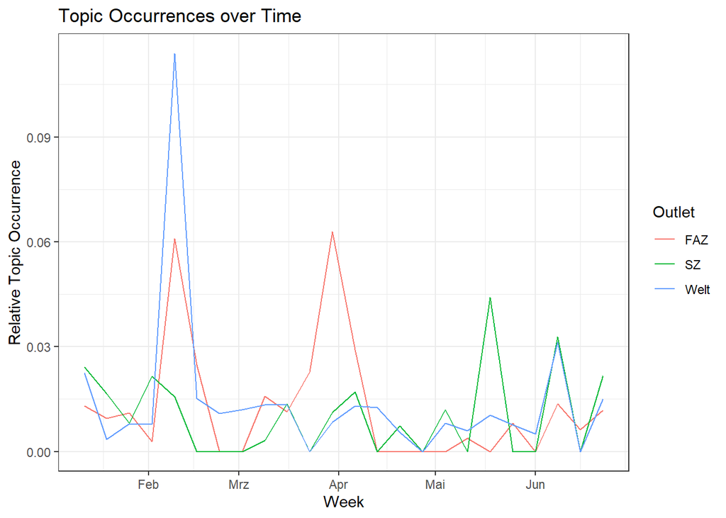

*Page Rank of Document: 0.09149813*

*Outlet: FAZ*

**Die BASF zeigt, wie Lobby geht**

*Beinahe hätte die BASF 400 Millionen Euro extra für die Energiewende zahlen müssen. Doch plötzlich ist davon keine Rede mehr. Sigmar Gabriel hat sich dem Druck der Strom-Selbsterzeuger gebeugt.*

*Page Rank of Document: 0.06868715*

*Outlet: Welt*

**EU nimmt Deutschlands Industrie in die Zange**

*EU-Kommissar Oettinger zeigt zwar Verständnis für die Strompreis-Sorgen der deutschen Industrie. Doch das Gefeilsche um Ökostrom-Rabatte und „Sektor- und Strukturlisten“ geht jetzt erst richtig los.*

*Page Rank of Document: 0.05737085*

*Outlet: FAZ*

**Sturmlauf gegen Gabriels Pläne**

*Die Wirtschaft kämpft für den selbsterzeugten Strom. BASF-Chef Kurt Bock sagt vor dem Treffen mit dem Minister in Berlin, im Ausland ernte er Mitleid und Spott.*

*Page Rank of Document: 0.0196973*

*Outlet: Welt*

**CDU-Vize kritisiert mit Brandbrief Gabriels Pläne**

*Julia Klöckner protestiert gegen die Energiepläne des Wirtschaftsministers. Der will die EEG-Umlage auf Strom erheben, den Unternehmen erzeugen. Klöckner befürchtet die Abwanderung von Betrieben.*

*Page Rank of Document: 0.0164067*

*Outlet: FAZ*

**Industrie warnt vor zu teurer EEG-Umlage**

*Vor dem Beschluss der Ökosteuerreform im Kabinett wächst der Druck auf Wirtschaftsminister Gabriel. „Die Sache ist extrem gefährlich“, warnt nicht nur Unionsfraktionsvize Fuchs.*

*Page Rank of Document: 0.01584393*

*Outlet: FAZ*

**Auch Strom-Selbstversorger sollen Ökoumlage zahlen**

*Bislang müssen Betriebe, die Strom selbst produzieren, darauf keine Ökostrom-Umlage zahlen. Das soll sich nach Informationen der F.A.Z. ändern. Die Stromrechnung der Industrie könnte um einen dreistelligen Millionenbetrag steigen.*

*Page Rank of Document: 0.0124534*

*Outlet: SZ*

**Gabriel setzt Privilegien für energieintensive Konzerne durch**

*Weil Deutschland Tausende Unternehmen von der EEG-Umlage befreit, hat die EU ein Verfahren gestartet. Nun konnte Wirtschaftsminister Gabriel jedoch einen Kompromiss aushandeln, der die besonders energieintensiven Betriebe weiterhin mit großzügigen Rabatten versieht.*

*Page Rank of Document: 0.01229375*

*Outlet: Welt*

**Industrie erbost über Schein-Reform des EEG**

*Die EEG-Reform soll die Ökostrom-Branche dem freien Spiel von Angebot und Nachfrage aussetzen. Augenwischerei, kritisiert die Industrie. Die geplante Novelle wirke lediglich wie eine Schein-Reform.*

*Page Rank of Document: 0.01215288*

*Outlet: FAZ*

**Deutschland setzt sich im Ökostrom-Streit gegen Brüssel durch**

*Die EU und Deutschland streiten über gewährte Ökostrom-Rabatte für Firmen, die viel Energie verbrauchen. Nun macht Brüssel gegenüber Berlin noch mehr Zugeständnisse.*

*Page Rank of Document: 0.01187608*

*Outlet: FAZ*

**Der Strom bleibt ein Rätsel**

*Die Länder dürfen mit dem Kompromiss über die EEG-Reform zufrieden sein. Der SPD-Vorsitzende Sigmar Gabriel aber auch. Nur die Stromkunden wissen noch nicht, was sie erwartet. Ein Kommentar.*

# Topic: 40

## Top Terms: Fußball-WM, Telekom, W-Lan, ICE, Bahnhof, Mobilfunknetz, Tunnel, Handy, Code, SMS, Handyempfang, Telekom-Hotspot-Logo, Scheibe, Berufstätige, Computer, Wohnzimmer, Kinderzimmer, Restaurant, Reisezeit, Daimler-Manager

## Topic Proportion: 1%

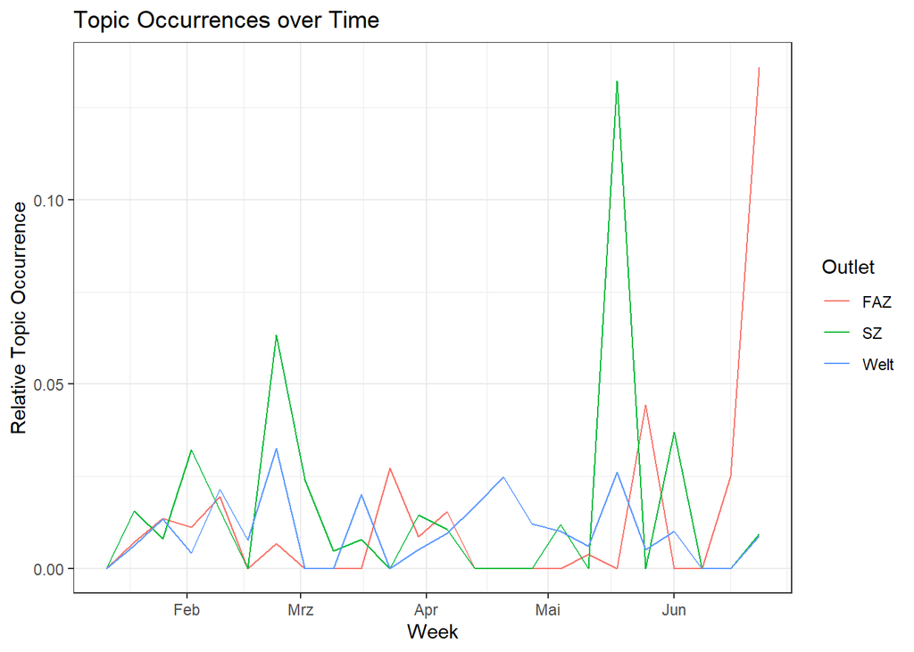

*Page Rank of Document: 0.143985*

*Outlet: FAZ*

**„Durch Fernbusse verlieren wir 50 Millionen Euro“**

*Von Frankfurt mal eben zu einer Ausstellung nach München - und zurück. Bahnchef Rüdiger Grube über das Leben im Zug, die Probleme mit dem Internet und das Geschacher der Politik um Bahnposten.*

*Page Rank of Document: 0.02832378*

*Outlet: SZ*

**Die Bonität der Bahn bröselt**

*Gleise und Brücken in Deutschland werden immer schlechter. Der Bahn fehlt für den Erhalt des Schienennetzes allerdings das Geld. Nun drohen dem verschuldeten Konzern auch noch höhere Zinszahlungen.*

*Page Rank of Document: 0.02402175*

*Outlet: FAZ*

**Höhere Bahn-Preise wegen EEG-Reform erwartet**

*Weil die Bahn künftig mehr Ökostrom-Umlage bezahlen soll, befürchten Verbraucherschützer, Gewerkschafter und die Schienen-Lobby höhere Ticketpreise.*

*Page Rank of Document: 0.02124216*

*Outlet: SZ*

**MVG fürchtet Zusatzkosten in Millionenhöhe**

*Zusätzliche Busse oder neue Trambahnen? Große Verbesserungen hat die MVG für dieses Jahr nicht geplant. Kaum kalkulierbar, heißt es. Denn schon bald könnte das Unternehmen an der EEG-Umlage beteiligt werden - mit bis zu 2,5 Millionen Euro.*

*Page Rank of Document: 0.01828699*

*Outlet: Welt*

**Neue Ökostrom-Regel könnte Bahnfahren verteuern**

*Die Deutsche Bahn soll künftig für die Energiewende stärker zur Kasse gebeten werden. Dagegen poltert nun die Schienen-Lobby: Zusätzliche Kosten würden „unweigerlich“ auf die Fahrpreise umgelegt.*

*Page Rank of Document: 0.01632627*

*Outlet: Welt*

**Bahn-Preise könnten um zehn Prozent steigen**

*Die Eisenbahngewerkschaft warnt davor, der Bahn die Vorteile bei der Ökostrom-Umlage wegzunehmen. Dann drohe nicht nur den Fahrgästen eine sprunghafte Preiserhöhung, sondern ein Verkehrsinfarkt.*

*Page Rank of Document: 0.01617895*

*Outlet: FAZ*

**Amerikas Autoverkäufe ziehen nach strengem Winter kräftig an**

*GM-Chefin Marry Barra stellt sich einem harten Verhör zu der tödlichen Pannenserie, Bundesverkehrsminister Dobrindt ruft Lufthansa und Piloten zu einer schnellen Einigung auf und der Wertpapierhandel der Deutsche Börse legt im März weiter zu.*

*Page Rank of Document: 0.0145452*

*Outlet: FAZ*

**Hilfe aus Brüssel im Ringen um EEG-Umlage**

*Rechenzentren brauchen sehr viel Strom, um arbeiten zu können. Die EEG-Umlage müssen sie trotzdem zahlen. Die EU stellt es dem Bund nun frei, diese in Frankfurt stark vertretene Branche zu entlasten. Doch der ziert sich.*

*Page Rank of Document: 0.01405729*

*Outlet: Welt*

**Staat verdient Milliarden durch steigende Strompreise**

*Mit mehr als 1,6 Milliarden Euro Einnahmen aus der Umsatzsteuer auf steigende Strompreise kann der Bund in diesem Jahr rechnen. Die Linke fordert, den Stromkunden das Geld zurückzugeben.*

*Page Rank of Document: 0.01404049*

*Outlet: FAZ*

**Für Energiewende und gegen Atomkraft**

*Mehrere tausend Menschen sind am Wochenende für den sofortigen Ausstieg aus der Kohle- und Atomenergie auf die Straße gegangen. Auch in Mainz und Wiesbaden.*

# Topic: 12

## Top Terms: Schienenverkehrs, Verkehrsträger, Kirchner, EVG, Verkehrsbetriebe, Ticketpreise, Verkehrsgewerkschaft, Dirk, Preisaufschlägen, Transportverlagerungen, Verkehrs-Betriebe, Tagesspiegel, Stadt-Anzeiger, Schienen-Unternehmen, Sigrid, Attraktivität, Gewerkschaftsvorsitzende, Autofahrern, Prozentpunkten, Flege

## Topic Proportion: 1%

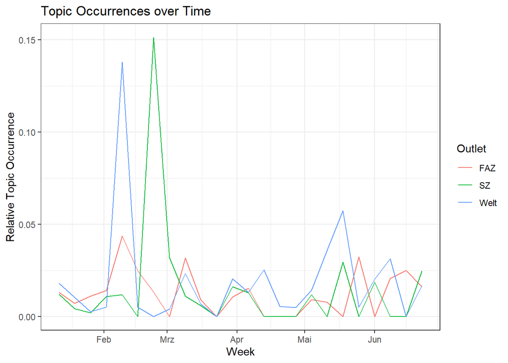

*Page Rank of Document: 0.1082248*

*Outlet: Welt*

**Neue Ökostrom-Regel könnte Bahnfahren verteuern**

*Die Deutsche Bahn soll künftig für die Energiewende stärker zur Kasse gebeten werden. Dagegen poltert nun die Schienen-Lobby: Zusätzliche Kosten würden „unweigerlich“ auf die Fahrpreise umgelegt.*

*Page Rank of Document: 0.06130068*

*Outlet: Welt*

**Tickets für Bus und Bahn werden teurer**

*Deutschland muss die Stromrabatte begrenzen. Deshalb dürften bald ausgerechnet die umweltbewussten Bus- und Bahnkunden mehr bezahlen müssen. Die Verkehrsbetriebe erwarten Preiserhöhungen.*

*Page Rank of Document: 0.05289755*

*Outlet: Welt*

**Bahn-Preise könnten um zehn Prozent steigen**

*Die Eisenbahngewerkschaft warnt davor, der Bahn die Vorteile bei der Ökostrom-Umlage wegzunehmen. Dann drohe nicht nur den Fahrgästen eine sprunghafte Preiserhöhung, sondern ein Verkehrsinfarkt.*

*Page Rank of Document: 0.037683*

*Outlet: SZ*

**Die Bonität der Bahn bröselt**

*Gleise und Brücken in Deutschland werden immer schlechter. Der Bahn fehlt für den Erhalt des Schienennetzes allerdings das Geld. Nun drohen dem verschuldeten Konzern auch noch höhere Zinszahlungen.*

*Page Rank of Document: 0.02679559*

*Outlet: FAZ*

**Höhere Bahn-Preise wegen EEG-Reform erwartet**

*Weil die Bahn künftig mehr Ökostrom-Umlage bezahlen soll, befürchten Verbraucherschützer, Gewerkschafter und die Schienen-Lobby höhere Ticketpreise.*

*Page Rank of Document: 0.0221909*

*Outlet: FAZ*

**Die teure neue Ökostrom-Welt**

*Wer leidet, wer profitiert nach der Einigung von Bund und Ländern zur Energiewende-Reform? Energieminister Gabriel stimmt die Wirtschaft schon darauf ein, dass sie zahlen muss. Und auch für die Verbraucher wird es teurer.*

*Page Rank of Document: 0.01956027*

*Outlet: Welt*

**Seehofer will EEG-Umlage bei acht Cent deckeln**

*Die Ökostrom-Umlage ist in den vergangenen Jahren kontinuierlich gestiegen – auf zuletzt 6,24 Cent je Kilowattstunde. Nun will CSU-Chef Horst Seehofer eine weiteren drastischen Anstieg verhindern.*

*Page Rank of Document: 0.0190509*

*Outlet: FAZ*

**Seehofer grätscht Gabriel dazwischen**

*Der bayerische Ministerpräsident verlangt einen radikalen Einschitt bei der Ökostrom-Förderung. Das Land will davon die Zustimmung zu den Plänen aus Berlin abhängig machen.*

*Page Rank of Document: 0.01901982*

*Outlet: SZ*

**Gabriel knickt vor Bahn ein**

*Privathaushalte zahlen die Öko-Umlage für erneuerbare Energien - viele Firmen hingegen erhalten Rabatte in Milliardenhöhe. Die Bahn sollte künftig eigentlich stärker belastet werden, Wirtschaftsminister Gabriel aber knickt ein. Eine Drohung von Bahnchef Grube scheint gewirkt zu haben.*

*Page Rank of Document: 0.01717406*

*Outlet: SZ*

**Dobrindt und Gabriel einigen sich auf Bahn-Abgabe**

*Bisher war die Deutsche Bahn fast vollständig von der Öko-Umlage befreit. Jetzt muss der Marktführer immerhin ein Fünftel der Abgabe bezahlen. Von der Neuregelung profitieren vor allem die kleinen Konkurrenten.*

# Topic: 9

## Top Terms: Dr., Hitschler, Dienstleistern, Pfalzwerke, Eigentümern, Reststromversicherung, Selbstversorger-Paket, Feldversuch, Testkunden, Smart-Meter-Technologie, Datensicherheit, Phantasie, Telekommunikations-Dienstleistungen, Zahlungsbereitschaft, Einbau, Zwangsbeglückung, Gefallen, Fremdstrombezug, Finanzierungsstruktur, Solarmodul

## Topic Proportion: 1%

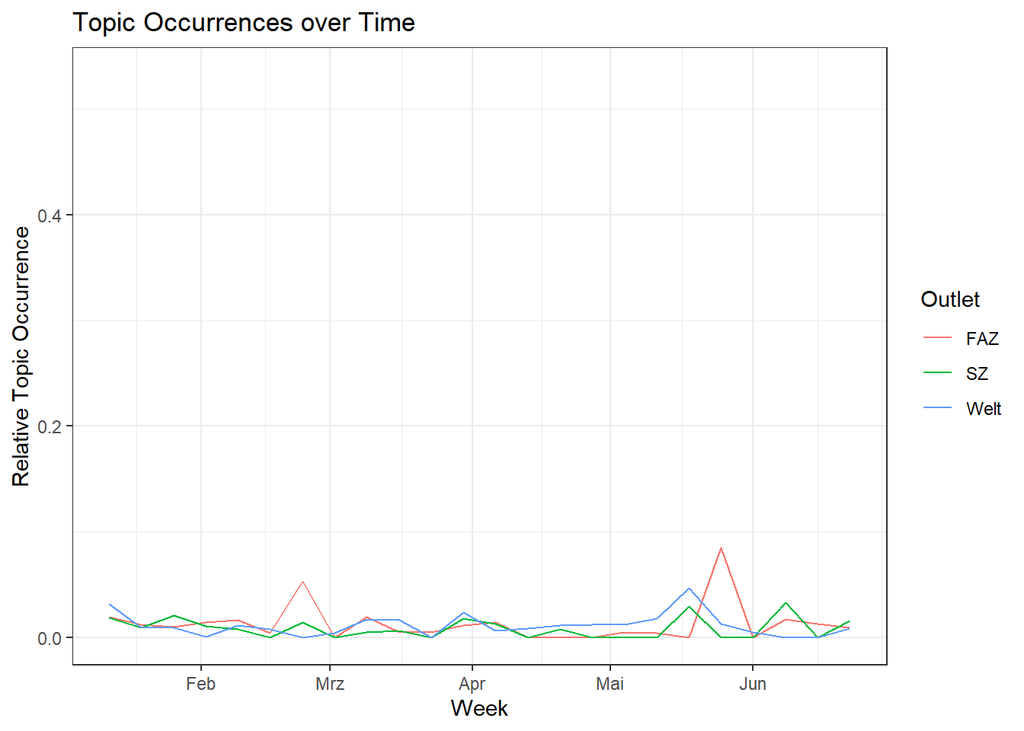

*Page Rank of Document: 0.1526711*

*Outlet: FAZ*

**Anstoß für neue Geschäftsfelder**

*Die Energieversorger suchen neue Geschäftsfelder jenseits der Lieferung von Strom, Gas und Wärme. Welche Leistungen und Produkte wünscht der Kunde? Wofür ist er bereit zu bezahlen? Dr. Werner Hitschler, Pfalzwerke, und Verbraucherschützer Dr. Holger Krawinkel richten den Blick auf aktuelle Herausforderungen und den Markt von morgen.*

*Page Rank of Document: 0.02310978*

*Outlet: FAZ*

**Verbraucher erzeugen immer mehr Strom selbst**

*Die Eigenstromerzeugung nimmt in Deutschland zu. Immer mehr Selbstverbraucher sparen sich die EEG-Umlage und Stromsteuern. Für die restlichen Kunden wird es dadurch teurer.*

*Page Rank of Document: 0.0171428*

*Outlet: Welt*

**Wie sich Sigmar Gabriel mit dem RWE-Chef anlegt**

*Energieminister Gabriel hat seine erste Grundsatzrede vor der Branche gehalten. Für seine Reformpläne erhielt er viel Applaus. In einem Punkt gerieten sich Minister und Manager aber doch in die Haare.*

*Page Rank of Document: 0.01306904*

*Outlet: Welt*

**Do-it-yourself-Ökostromer gegen Gabriel**

*Eine Allianz aus Verbraucherschützern, Landwirten und Mietern kritisiert die Reform des Erneuerbare-Energien-Gesetzes: Es sei unsinnig, Ökostrom für den Eigenverbrauch mit der EEG-Umlage zu belasten.*

*Page Rank of Document: 0.01235585*

*Outlet: SZ*

**Gabriel spielt das Merkel-Echo**

*Spricht da der heimliche Kanzler? SPD-Chef Sigmar Gabriel wirbt im Bundestag für seine Energiewende. Die Grünen umschmeichelt er, ebenso CSU-Verkehrsminister Dobrindt. Aus seiner Partei muss er sich jedoch anhören, er betreibe Planwirtschaft.*

*Page Rank of Document: 0.01226712*

*Outlet: Welt*

**Was die Länder gegen Gabriels Öko-Pläne aufbringt**

*Die Pläne des Wirtschaftsministers zum Umbau der Ökostrom-Förderung stoßen auf den Widerstand der Bundesländern. Denn jedes verfolgt eigene Interessen – und hat andere Energie-Schwerpunkte.*

*Page Rank of Document: 0.01213519*

*Outlet: Welt*

**Endspiel um Gabriels Energiewende-Reform**

*Die Energiewende ist das zentrale Großprojekt von Schwarz-Rot. Beim Gipfel streiten Bund und Länder, wie es weitergehen soll. Alle Antworten auf die wichtigsten EEG-Reform-Fragen.*

*Page Rank of Document: 0.01168249*

*Outlet: SZ*

**Teurer Kompromiss**

*Bundesregierung und Länder feiern sich und ihre Einigung beim Strom-Gipfel. Aber geht das - Zufriedenheit auf allen Seiten? Wer profitiert, wer hat das Nachsehen? Die wichtigsten Fragen und Antworten zur geplanten Reform des Erneuerbare-Energien-Gesetzes.*

*Page Rank of Document: 0.01090418*

*Outlet: Welt*

**Eigenversorger treiben Strompreis in neue Höhen**

*Die Bundesregierung will die Ökostrom-Umlage „stabilisieren“. Doch nach Ansicht von Experten wird das nicht funktionieren, weil immer mehr Unternehmen und Bürger ihren Strom selbst produzieren.*

*Page Rank of Document: 0.01045074*

*Outlet: FAZ*

**Wirtschaft entsetzt über Gabriel**

*Die Belastungen für die gesamte Wirtschaft werden bei den von der Regierung geplanten Kosten von einem Cent je Kilowattstunde auf 500 Millionen Euro im Jahr geschätzt.*

# Topic: 32

## Top Terms: Jahr

## Topic Proportion: 1%

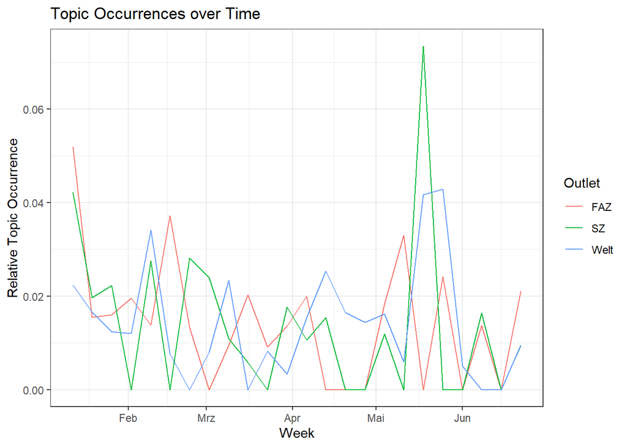

*Term Frequency of Document: 0.1333333*

*Outlet: Welt*

**Hunderte weitere Firmen von EEG-Umlage entlastet**

*2098 Unternehmen werden in diesem Jahr von der EEG-Umlage entlastet – 378 mehr als 2013. Die Ausnahmen summieren sich auf mehr als fünf Milliarden Euro. Die EU sieht darin eine Wettbewerbsverzerrung.*

*Term Frequency of Document: 0.06756757*

*Outlet: SZ*

**2098 Unternehmen sparen sich EEG-Umlage**

*Privathaushalte werden noch mehr belastet: Die Zahl der von der umstrittenen EEG-Umlage befreiten Unternehmen steigt um mehr als 20 Prozent. Dabei wollte die Bundesregierung die Zahl doch verringern.*

*Term Frequency of Document: 0.06593407*

*Outlet: Welt*

**Windkraftbranche fürchtet sich vor Gabriels Plänen**

*In Deutschland wurden so viele neue Windkraft-Anlagen gebaut wie seit zehn Jahren nicht. Doch die Branche klagt über schlechtes Investitionsklima und über die Vorhaben des Bundeswirtschaftsministers.*

*Term Frequency of Document: 0.06410256*

*Outlet: Welt*

**Das grüne Jobwunder fällt in sich zusammen**

*Erneuerbare Energien sollten Zehntausende Jobs schaffen. Doch trotz milliardenschwerer Beihilfen sinkt die Zahl der Arbeitsplätze. Sieben von zehn Stellen gibt es nur, solange Subventionen fließen.*

*Term Frequency of Document: 0.05555556*

*Outlet: Welt*

**Staat verdient Milliarden durch steigende Strompreise**

*Mit mehr als 1,6 Milliarden Euro Einnahmen aus der Umsatzsteuer auf steigende Strompreise kann der Bund in diesem Jahr rechnen. Die Linke fordert, den Stromkunden das Geld zurückzugeben.*

*Term Frequency of Document: 0.05*

*Outlet: Welt*

**Windbranche reicht Gabriels Absatzgarantie nicht**

*Energieminister Gabriel will einen Windkraft-Ausbau von 2500 Megawatt pro Jahr gesetzlich garantieren. Das liegt über dem Durchschnitt der vergangenen zehn Jahre. Der Windbranche ist das nicht genug.*

*Term Frequency of Document: 0.04545455*

*Outlet: FAZ*

**Wer gewinnt, wer verliert?**

*An diesem Freitag hat der Bundestag die Reform der Ökostromförderung beschlossen. Sie tritt im August in Kraft. Die wichtigsten Fragen und Antworten zum neuen EEG.*

*Term Frequency of Document: 0.04464286*

*Outlet: Welt*

**Schleswig-Holstein deckt Strombedarf ökologisch**

*2014 wird Schleswig-Holstein seinen Strombedarf wohl mit Ökostrom decken, in den kommenden Jahren will es gar zum Ökostrom-Exporteur werden. Umweltminister Habeck sieht das Land in der Poleposition.*

*Term Frequency of Document: 0.04347826*

*Outlet: SZ*

**Wind aus allen Richtungen**

*Die Förderung von Ökostrom soll reformiert werden. Aber wie? Die Interessen von Anbietern, Kommunen, Bundesländern und Industrie klaffen auseinander. Und Sigmar Gabriel muss eine Lösung finden, mit der alle leben können - einigermaßen.*

*Term Frequency of Document: 0.04166667*

*Outlet: Welt*

**Bau neuer Solaranlagen geht um 56 Prozent zurück**

*Die Kappung der Förderung für Solaranlagen hat den Aufbau neuer Anlagen deutlich gebremst. So wurde im vergangenen Jahr 56 Prozent weniger Kapazität neu installiert als im Vorjahr.*

# Topic: 20

## Top Terms: Schlachtbetriebe, Arnold, Stromabnahmestellen, Ernährungsgewerbe, Roheisen, Bafa-Präsident, Wallraff, Investitionsentscheidungen, Salzabbau, Snack, Speiseeishersteller, Verarbeiter, Zeitungsdruckereien, Gasförderung, World, Tchibo, EU-Beihilfe-Leitlinien, Obstverarbeiter, Fruchtsaftproduzenten, Strumpfhersteller

## Topic Proportion: 1%

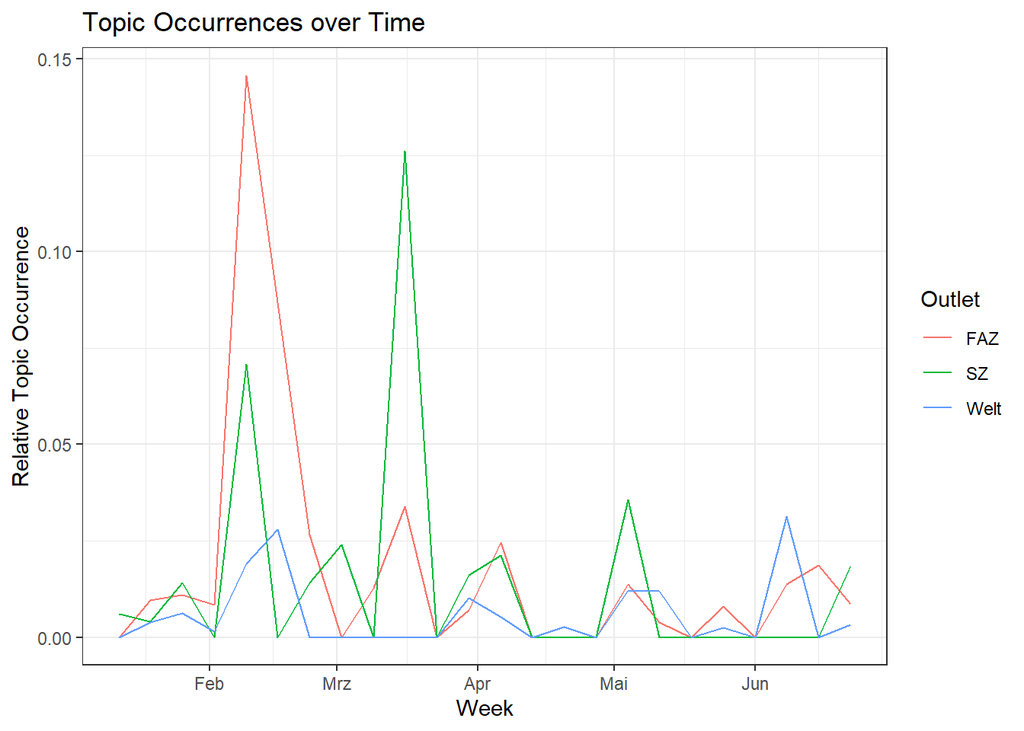

*Page Rank of Document: 0.1042106*

*Outlet: FAZ*

**Neue Ökostromrabatte für Verkehrsbetriebe und Molkereien**

*Zahlreiche städtische Verkehrsunternehmen, Schlachtbetriebe und Molkereien gehören zu den Unternehmen, die für 2014 von der vollen Zahlung der EEG-Umlage befreit wurden. Das geht aus einer Auflistung des Bundesamtes für Wirtschaft und Ausfuhrkontrolle hervor.*

*Page Rank of Document: 0.09560368*

*Outlet: FAZ*

**Stromrabatte für Stadtbusse und Molkereien**

*Viel mehr Unternehmen sind von der Ökostrom-Umlage befreit als gedacht: Auch städtische Verkehrsunternehmen, Schlachtbetriebe und Molkereien werden begünstigt.*

*Page Rank of Document: 0.06462135*

*Outlet: SZ*

**Mehr als 100 Branchen sollen Ökostrom-Rabatt verlieren**

*Speiseeishersteller und Schlachtbetriebe könnten bald für die Energiewende mitzahlen: Einem Entwurf der EU zufolge sollen zwei Drittel der Branchen, die bisher von der EEG-Umlage befreit sind, diese Vergünstigung verlieren. Wem Nachteile drohen, wer weiter profitiert - ein Überblick.*

*Page Rank of Document: 0.03213751*

*Outlet: SZ*

**2098 Unternehmen sparen sich EEG-Umlage**

*Privathaushalte werden noch mehr belastet: Die Zahl der von der umstrittenen EEG-Umlage befreiten Unternehmen steigt um mehr als 20 Prozent. Dabei wollte die Bundesregierung die Zahl doch verringern.*

*Page Rank of Document: 0.0276182*

*Outlet: Welt*

**Hunderte weitere Firmen von EEG-Umlage entlastet**

*2098 Unternehmen werden in diesem Jahr von der EEG-Umlage entlastet – 378 mehr als 2013. Die Ausnahmen summieren sich auf mehr als fünf Milliarden Euro. Die EU sieht darin eine Wettbewerbsverzerrung.*

*Page Rank of Document: 0.02171264*

*Outlet: FAZ*

**Sturmlauf gegen Gabriels Pläne**

*Die Wirtschaft kämpft für den selbsterzeugten Strom. BASF-Chef Kurt Bock sagt vor dem Treffen mit dem Minister in Berlin, im Ausland ernte er Mitleid und Spott.*

*Page Rank of Document: 0.01689505*

*Outlet: FAZ*

**EU bietet 65 Branchen Ökostromrabatt an**

*Lange wollte der Wettbewerbskommissar die Stromrabatte für energieintensive Unternehmen abschaffen. Nun kommt er Deutschland entgegen - eine handfeste Überraschung.*

*Page Rank of Document: 0.01637944*

*Outlet: FAZ*

**EEG-Umlage: Welche Firmen müssen künftig zahlen?**

*Die EU-Kommission verlangt, weniger deutsche Firmen von der EEG-Umlage zu befreien und schlägt einen Kompromiss vor. Wir zeigen, welche Branchen weiterhin günstig davon kommen - und wer künftig vielleicht zahlen muss.*

*Page Rank of Document: 0.01569241*

*Outlet: FAZ*

**Deutsche Industrie für weniger Ökostrom-Rabatte**

*Zwischen Deutschland und der EU-Kommission gibt es Streit über die Ökostrom-Umlage. Nun findet auch die deutsche Industrie, dass es zu viele Ausnahmen gibt: Zum Beispiel für den Schienenverkehr.*

*Page Rank of Document: 0.01488219*

*Outlet: SZ*

**Auch EU schont Industrie**

*Konzerne, die viel Strom verbrauchen, müssen nicht um ihre Privilegien fürchten: Nach der Bundesregierung kommt auch die EU der Industrie entgegen. Staaten dürfen nach den neuen Energie-Leitlinien ausgewählte Branchen von den Kosten der Ökostrom-Förderung entlasten.*

# Topic: 14

## Top Terms: Schuldenkrise, Generaldebatte, Stärken, zulasten, Datenschutzniveau, Kooperationsbereitschaft, Interessenausgleichs, Affäre, Kipping, Regen, Ukrainer, NSA, Katja, Tod, Armut, Kürzungspolitik, Hilfeleistung, Krankheit, Haushaltsentwurf, Bekämpfung

## Topic Proportion: 1%

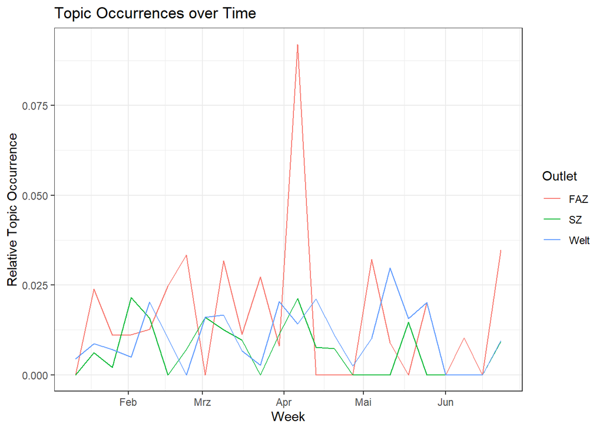

*Page Rank of Document: 0.1034945*

*Outlet: FAZ*

**„Die Ukrainer müssen über ihr Schicksal selber entscheiden“**

*Kanzlerin Merkel hat Moskau aufgefordert, sich endlich mit der neuen ukrainischen Regierung an einen Tisch zu setzen. Zudem zog sie eine positive Bilanz der Arbeit der großen Koalition. Ein ausgeglichener Haushalt liege in greifbarer Nähe.*

*Page Rank of Document: 0.03736128*

*Outlet: FAZ*

**Merkel: „Deutschland bleibt Stabilitätsanker“**

*Im Bundestag wird über den Haushalt für das kommende Jahr debattiert. Dass Gregor Gysi der Koalition eine verfehlte Haushalts- und Finanzpolitik vorwirft, lässt die Kanzlerin kalt.*

*Page Rank of Document: 0.02239195*

*Outlet: FAZ*

**Gabriel beißt in Brüssel mit Ökostromreform auf Granit**

*Sigmar Gabriel sagt das Berliner Energietreffen ab. Der Wirtschaftsminister konnte bei seinem Brüssel-Besuch „keine Grundlage für eine Diskussion erzielen“.*

*Page Rank of Document: 0.02210134*

*Outlet: FAZ*

**Todesstoß für Ökostromförderung**

*Offenbar braucht es die EU, um den Deutschen auf teure Weise klarzumachen, dass das Subventionsmonster EEG unbezahlbar ist.*

*Page Rank of Document: 0.01753484*

*Outlet: Welt*

**„Bayern darf nicht Hintersasse der Nordsee werden“**

*Der neue CSU-Agrarminister Christian Schmidt fordert SPD-Wirtschaftsminister Gabriel (SPD) zu weiteren Nachbesserungen an seinem Energiekonzept auf – vor allem bei der Bioenergie.*

*Page Rank of Document: 0.01557561*

*Outlet: Welt*

**Windkraft auf hoher See lohnt sich bald nicht mehr**

*Die Kostenbremse durch die geplante EEG-Reform bedeutet auch, dass bei Investoren künftig weniger Geld ankommt. Das könnte für den Ausbau der Offshore-Windenergie das Aus bedeuten.*

*Page Rank of Document: 0.01408072*

*Outlet: Welt*

**Wie sich Sigmar Gabriel mit dem RWE-Chef anlegt**

*Energieminister Gabriel hat seine erste Grundsatzrede vor der Branche gehalten. Für seine Reformpläne erhielt er viel Applaus. In einem Punkt gerieten sich Minister und Manager aber doch in die Haare.*

*Page Rank of Document: 0.01326362*

*Outlet: SZ*

**Brüssel verlangt Nachbesserungen beim EEG**

*Die Reform des Ökostrom-Gesetzes, das Kabinettstück von Wirtschaftsminister Gabriel, sollte mit Tempo den Bundestag passieren. Doch jetzt gibt es Probleme auf den letzten Metern.*

*Page Rank of Document: 0.01233372*

*Outlet: FAZ*

**Deutschland setzt sich im Ökostrom-Streit gegen Brüssel durch**

*Die EU und Deutschland streiten über gewährte Ökostrom-Rabatte für Firmen, die viel Energie verbrauchen. Nun macht Brüssel gegenüber Berlin noch mehr Zugeständnisse.*

*Page Rank of Document: 0.01210121*

*Outlet: SZ*

**Diplomatie auf Kosten der Verbraucher**

*Bei der EEG -Reform will Wirtschaftsminister Gabriel es allen recht machen. Die Industrie behält ihre Rabatte, die Ökobranche ihre Förderung. Der Verbraucher zahlt. Aber der entscheidet am Ende auch über seinen Erfolg als Energieminister.*

# Topic: 18

## Top Terms: Terrasse, Feichtner, Streitobjekt, Voralpenland, Erwägung, Kuhstall, Milchpreis, Nachbarhof, Gras, Arbeitskleidung, Gummistiefel, Mütze, Irrenhaus, Biogas-Epoche, Spuk, Rosenheim, Biogas-Bauern, Garantie-Jahre, Kleinstanlagen, Biogas-Strom

## Topic Proportion: 1%

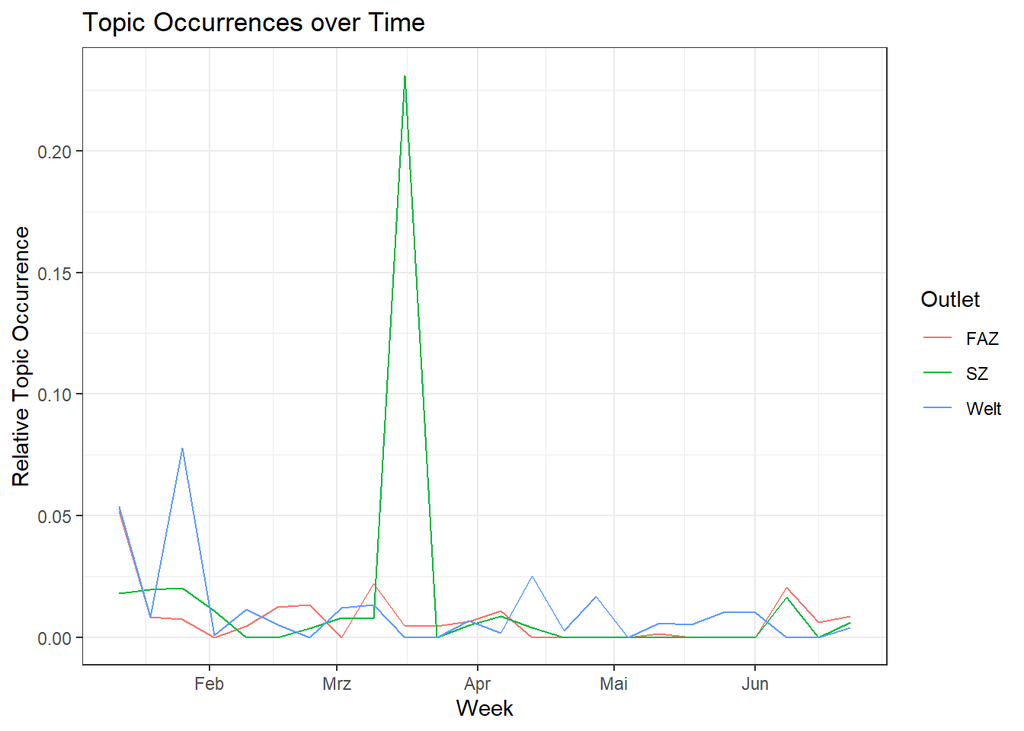

*Page Rank of Document: 0.1301672*

*Outlet: SZ*

**Biogas wird abgedreht**

*Viele Bauern waren stolz, an der Energiewende beteiligt zu sein - und froh über das neue Standbein. Nun hat der Biogas-Boom ein Ende. Die Bundesregierung reformiert die Förderrichtlinien, neue Anlagen lohnen sich dann nicht mehr. Einige Experten halten das für einen Fehler.*

*Page Rank of Document: 0.07421467*

*Outlet: Welt*

**Gabriels Energiereform bedroht 1000 Offshore-Jobs**

*Gewerkschafter fürchten, dass in den kommenden Wochen weitere 1000 Stellen in der Windkraftindustrie wegfallen. Grund dafür soll die ambitionierte Reform von Wirtschaftsminister Sigmar Gabriel sein.*

*Page Rank of Document: 0.02497959*

*Outlet: Welt*

**Deutsche verschmähen einst geliebte Solaranlagen**

*Es war eine idiotensichere Geldanlage: Für Solarmodule auf dem Dach garantierte der Staat eine Top-Rendite. Jetzt, wo die Fördersätze gekürzt sind, bricht die Nachfrage ein.*

*Page Rank of Document: 0.02143014*

*Outlet: SZ*

**Wind aus allen Richtungen**

*Die Förderung von Ökostrom soll reformiert werden. Aber wie? Die Interessen von Anbietern, Kommunen, Bundesländern und Industrie klaffen auseinander. Und Sigmar Gabriel muss eine Lösung finden, mit der alle leben können - einigermaßen.*

*Page Rank of Document: 0.01882071*

*Outlet: Welt*

**Was die Länder gegen Gabriels Öko-Pläne aufbringt**

*Die Pläne des Wirtschaftsministers zum Umbau der Ökostrom-Förderung stoßen auf den Widerstand der Bundesländern. Denn jedes verfolgt eigene Interessen – und hat andere Energie-Schwerpunkte.*

*Page Rank of Document: 0.01688857*

*Outlet: Welt*

**Gabriel will Privilegien für Unternehmen beschneiden**

*Wirtschaftsminister Gabriel (SPD) hat ein Eckpunktepapier für eine Energiewende-Reform vorgelegt. Um den Anstieg der Stromkosten zu bremsen, sollen Unternehmen auf Vergünstigungen verzichten.*

*Page Rank of Document: 0.01655124*

*Outlet: Welt*

**Windkraft auf hoher See lohnt sich bald nicht mehr**

*Die Kostenbremse durch die geplante EEG-Reform bedeutet auch, dass bei Investoren künftig weniger Geld ankommt. Das könnte für den Ausbau der Offshore-Windenergie das Aus bedeuten.*

*Page Rank of Document: 0.01543186*

*Outlet: SZ*

**SPD-Ministerpräsident Albig kritisiert Gabriels Windkraft-Pläne**

*Bundeswirtschaftsminister Sigmar Gabriel will den Ausbau der Windkraft drosseln, nun erntet er dafür Widerspruch aus der eigenen Partei. Schleswig-Holsteins Ministerpräsident Torsten Albig findet die Idee “unsinnig” - und präsentiert einen Gegenvorschlag.*

*Page Rank of Document: 0.01431629*

*Outlet: Welt*

**„Flatterstrom“ gefährdet Stabilität der Netze**

*Gabriels EEG-Novelle setzt vor allem auf wetterabhängige Ökostrom-Quellen. Die aber liefern unzuverlässig Strom. Dabei gäbe es umweltfreundliche und sichere Alternativen. Doch die werden blockiert.*

*Page Rank of Document: 0.0130455*

*Outlet: SZ*

**Mit Biomasse auf Wählerfang**

*Eine Regierungsklausur ohne CSU-Gepolter, das geht einfach nicht. Beim Thema Biomasse sucht die Regionalpartei den Konflikt mit SPD-Superminister Gabriel. Kein Wunder, die Hälfte der deutschen Anlagen steht in Bayern - und bald ist dort Kommunalwahl.*